# Exercise 3

This exercise requires setting up `multipleGroup()` for estimating multiple-group models, and includes a DIF search. The data is available in the `Exercise_03.Rdata` file.

Load the dataset into R using the `load()` function, and inspect the defined objects. The object named `data` represents a 20-item dichtomously scored test. The `group` object consists of two groups: a set of individuals that had been trained in test taking skills (`with_training`) and a set of individuals without any training (`without_training`).

### 1) Explore the dataset, and determine the dimensionality with `mirt()` (could be different across groups, but assume that it isn't for now).

```r
library(mirt)
load('Exercise_03.Rdata')
table(group)
```

```
## group
## without_training    with_training
##             1000             1000
```

```r
head(data)
```

```
##      Item_1 Item_2 Item_3 Item_4 Item_5 Item_6 Item_7 Item_8 Item_9
## [1,]      0      0      0      1      0      0      1      1      0
## [2,]      1      1      0      0      0      0      1      1      1
## [3,]      1      1      1      0      1      1      1      1      1
## [4,]      0      0      0      0      0      0      0      1      0
## [5,]      1      0      1      0      1      1      1      1      1
## [6,]      1      0      0      0      1      0      1      1      1
##      Item_10 Item_11 Item_12 Item_13 Item_14 Item_15 Item_16 Item_17
## [1,]       1       0       0       0       0       0       1       0
## [2,]       0       1       1       1       0       1       1       1
## [3,]       0       1       1       1       1       0       1       1
## [4,]       0       0       0       0       0       0       0       0
## [5,]       1       1       0       1       0       0       0       1
## [6,]       0       1       1       0       1       1       1       1
##      Item_18 Item_19 Item_20
## [1,]       1       0       0
## [2,]       0       0       1
## [3,]       1       0       1
## [4,]       0       0       0
## [5,]       1       1       1
## [6,]       1       1       1
```

```r
mod1 <- mirt(data, 1)
```

```
##
Iteration: 1, Log-Lik: -23087.203, Max-Change: 0.71338
Iteration: 2, Log-Lik: -22600.089, Max-Change: 0.34008
Iteration: 3, Log-Lik: -22500.753, Max-Change: 0.29897
Iteration: 4, Log-Lik: -22459.606, Max-Change: 0.16363
Iteration: 5, Log-Lik: -22441.177, Max-Change: 0.11083
Iteration: 6, Log-Lik: -22432.079, Max-Change: 0.07520
Iteration: 7, Log-Lik: -22427.936, Max-Change: 0.05935
Iteration: 8, Log-Lik: -22425.843, Max-Change: 0.03423
Iteration: 9, Log-Lik: -22424.859, Max-Change: 0.03275
Iteration: 10, Log-Lik: -22424.215, Max-Change: 0.01310
Iteration: 11, Log-Lik: -22424.006, Max-Change: 0.00985
Iteration: 12, Log-Lik: -22423.885, Max-Change: 0.00711
Iteration: 13, Log-Lik: -22423.722, Max-Change: 0.00253
Iteration: 14, Log-Lik: -22423.702, Max-Change: 0.00192
Iteration: 15, Log-Lik: -22423.687, Max-Change: 0.00187
Iteration: 16, Log-Lik: -22423.634, Max-Change: 0.00137
Iteration: 17, Log-Lik: -22423.632, Max-Change: 0.00086
Iteration: 18, Log-Lik: -22423.630, Max-Change: 0.00083
Iteration: 19, Log-Lik: -22423.624, Max-Change: 0.00033
Iteration: 20, Log-Lik: -22423.624, Max-Change: 0.00017
Iteration: 21, Log-Lik: -22423.624, Max-Change: 0.00017
Iteration: 22, Log-Lik: -22423.623, Max-Change: 0.00020
Iteration: 23, Log-Lik: -22423.623, Max-Change: 0.00017
Iteration: 24, Log-Lik: -22423.623, Max-Change: 0.00015
Iteration: 25, Log-Lik: -22423.622, Max-Change: 0.00008
```

```r
mod2 <- mirt(data, 2)
```

```
##
Iteration: 1, Log-Lik: -24795.754, Max-Change: 0.73440
Iteration: 2, Log-Lik: -22940.079, Max-Change: 0.41365
Iteration: 3, Log-Lik: -22621.100, Max-Change: 0.26164
Iteration: 4, Log-Lik: -22513.131, Max-Change: 0.24317
Iteration: 5, Log-Lik: -22464.161, Max-Change: 0.17415
Iteration: 6, Log-Lik: -22440.563, Max-Change: 0.10763
Iteration: 7, Log-Lik: -22428.694, Max-Change: 0.07923
Iteration: 8, Log-Lik: -22422.452, Max-Change: 0.05993
Iteration: 9, Log-Lik: -22418.898, Max-Change: 0.03863
Iteration: 10, Log-Lik: -22415.086, Max-Change: 0.02081
Iteration: 11, Log-Lik: -22414.327, Max-Change: 0.01656
Iteration: 12, Log-Lik: -22413.759, Max-Change: 0.00957
Iteration: 13, Log-Lik: -22412.780, Max-Change: 0.00725
Iteration: 14, Log-Lik: -22412.553, Max-Change: 0.00716
Iteration: 15, Log-Lik: -22412.375, Max-Change: 0.00681
Iteration: 16, Log-Lik: -22411.740, Max-Change: 0.00488
Iteration: 17, Log-Lik: -22411.699, Max-Change: 0.00470
Iteration: 18, Log-Lik: -22411.669, Max-Change: 0.00467
Iteration: 19, Log-Lik: -22411.528, Max-Change: 0.00422
Iteration: 20, Log-Lik: -22411.513, Max-Change: 0.00452
Iteration: 21, Log-Lik: -22411.497, Max-Change: 0.00454
Iteration: 22, Log-Lik: -22411.407, Max-Change: 0.00452
Iteration: 23, Log-Lik: -22411.393, Max-Change: 0.00450
Iteration: 24, Log-Lik: -22411.379, Max-Change: 0.00448
Iteration: 25, Log-Lik: -22411.296, Max-Change: 0.00437
Iteration: 26, Log-Lik: -22411.282, Max-Change: 0.00436
Iteration: 27, Log-Lik: -22411.269, Max-Change: 0.00434
Iteration: 28, Log-Lik: -22411.189, Max-Change: 0.00389
Iteration: 29, Log-Lik: -22411.177, Max-Change: 0.00384
Iteration: 30, Log-Lik: -22411.165, Max-Change: 0.00381
Iteration: 31, Log-Lik: -22411.094, Max-Change: 0.00388
Iteration: 32, Log-Lik: -22411.081, Max-Change: 0.00369
Iteration: 33, Log-Lik: -22411.070, Max-Change: 0.00364
Iteration: 34, Log-Lik: -22411.002, Max-Change: 0.00341
Iteration: 35, Log-Lik: -22410.991, Max-Change: 0.00342
Iteration: 36, Log-Lik: -22410.980, Max-Change: 0.00341
Iteration: 37, Log-Lik: -22410.915, Max-Change: 0.00326
Iteration: 38, Log-Lik: -22410.905, Max-Change: 0.00322
Iteration: 39, Log-Lik: -22410.894, Max-Change: 0.00319
```

[output cut: 446 more lines]

```
Iteration: 486, Log-Lik: -22408.480, Max-Change: 0.00014
Iteration: 487, Log-Lik: -22408.479, Max-Change: 0.00014
Iteration: 488, Log-Lik: -22408.479, Max-Change: 0.00014
Iteration: 489, Log-Lik: -22408.479, Max-Change: 0.00014
Iteration: 490, Log-Lik: -22408.478, Max-Change: 0.00014
Iteration: 491, Log-Lik: -22408.478, Max-Change: 0.00014
Iteration: 492, Log-Lik: -22408.478, Max-Change: 0.00014
Iteration: 493, Log-Lik: -22408.477, Max-Change: 0.00014
Iteration: 494, Log-Lik: -22408.477, Max-Change: 0.00014
Iteration: 495, Log-Lik: -22408.477, Max-Change: 0.00014
Iteration: 496, Log-Lik: -22408.476, Max-Change: 0.00014
Iteration: 497, Log-Lik: -22408.476, Max-Change: 0.00014
Iteration: 498, Log-Lik: -22408.475, Max-Change: 0.00014
Iteration: 499, Log-Lik: -22408.475, Max-Change: 0.00014
Iteration: 500, Log-Lik: -22408.474, Max-Change: 0.00014
```

```
## EM cycles terminated after 500 iterations.
```

```r
anova(mod1, mod2) #unidimensional appears to be fine
```

```
##
## Model 1: mirt(data = data, model = 1)
## Model 2: mirt(data = data, model = 2)
```

```
##        AIC     AICc    SABIC      BIC    logLik     X2  df      p
## 1 44927.24 44928.92 45024.20 45151.28 -22423.62    NaN NaN    NaN
## 2 44934.95 44938.60 45077.96 45265.40 -22408.47 30.296  19 0.0482
```

### 2) Use `itemfit()` to determine if there are any aberrant items in the unidimensional model according to the S-X2 statistic. Use a false-discovery rate adjustment, such as the Benjamini and Hochberg adjustment, to control for multiple comparisons when inspecting the \(p\)-values (found in the `p.adjust()` function).

```r
fit <- itemfit(mod1)
fit
```

```
##       item     Zh    S_X2 df.S_X2 p.S_X2
## 1   Item_1 1.9769 21.7993      17 0.1926
## 2   Item_2 2.2818 38.5962      17 0.0020
## 3   Item_3 2.4339 29.9362      17 0.0268
## 4   Item_4 2.9315 10.4637      16 0.8413
## 5   Item_5 3.1972 13.5965      16 0.6287
## 6   Item_6 2.2261 16.7100      17 0.4742
## 7   Item_7 2.9183 21.2008      16 0.1709
## 8   Item_8 2.1581 12.9224      17 0.7414
## 9   Item_9 2.4121 18.8849      17 0.3352
## 10 Item_10 3.1050 21.4008      16 0.1636
## 11 Item_11 3.2676 11.7612      16 0.7602
## 12 Item_12 3.6598 15.7208      16 0.4726
## 13 Item_13 2.4577 15.4830      17 0.5607
## 14 Item_14 2.5970 17.8869      17 0.3960
## 15 Item_15 2.8212  6.3627      16 0.9837
## 16 Item_16 2.8140 23.8454      16 0.0929
## 17 Item_17 1.8489 14.9842      17 0.5966
## 18 Item_18 1.9409 19.4301      17 0.3044
## 19 Item_19 2.6094 14.5314      17 0.6292
## 20 Item_20 1.6674  9.4825      17 0.9239
```

```r
#adjust the S-X2 values for false-discovery
p.adjust(fit$p.S_X2, method = 'fdr')
```

```
##  [1] 0.6420000 0.0400000 0.2680000 0.9347778 0.8389333 0.8389333 0.6420000
##  [8] 0.8943529 0.8380000 0.6420000 0.8943529 0.8389333 0.8389333 0.8389333
## [15] 0.9837000 0.6193333 0.8389333 0.8380000 0.8389333 0.9725263
```

### 3) Fit a completely independent multiple group model to the data with `multipleGroup()`, as well as the completely equal model, and view the estimated coefficients. Plot the independent model's test score and information plots (`type = 'score'` and `'info'`), and plot a few items tracelines with `itemplot()`.

```r
#completely independent
mod.ind <- multipleGroup(data, 1, group=group)
```

```
##
Iteration: 1, Log-Lik: -23087.203, Max-Change: 0.93446
Iteration: 2, Log-Lik: -22437.665, Max-Change: 0.40803
Iteration: 3, Log-Lik: -22300.535, Max-Change: 0.24414
Iteration: 4, Log-Lik: -22238.576, Max-Change: 0.15137
Iteration: 5, Log-Lik: -22212.513, Max-Change: 0.13477
Iteration: 6, Log-Lik: -22196.281, Max-Change: 0.08028
Iteration: 7, Log-Lik: -22185.792, Max-Change: 0.06319
Iteration: 8, Log-Lik: -22179.020, Max-Change: 0.05588
Iteration: 9, Log-Lik: -22174.503, Max-Change: 0.06322
Iteration: 10, Log-Lik: -22166.680, Max-Change: 0.04069
Iteration: 11, Log-Lik: -22164.831, Max-Change: 0.02950
Iteration: 12, Log-Lik: -22163.929, Max-Change: 0.02025
Iteration: 13, Log-Lik: -22162.722, Max-Change: 0.01888
Iteration: 14, Log-Lik: -22162.267, Max-Change: 0.01677
Iteration: 15, Log-Lik: -22161.903, Max-Change: 0.01456
Iteration: 16, Log-Lik: -22160.674, Max-Change: 0.00801
Iteration: 17, Log-Lik: -22160.605, Max-Change: 0.00482
Iteration: 18, Log-Lik: -22160.565, Max-Change: 0.00544
Iteration: 19, Log-Lik: -22160.485, Max-Change: 0.00306
Iteration: 20, Log-Lik: -22160.470, Max-Change: 0.00314
Iteration: 21, Log-Lik: -22160.457, Max-Change: 0.00277
Iteration: 22, Log-Lik: -22160.406, Max-Change: 0.00697
Iteration: 23, Log-Lik: -22160.399, Max-Change: 0.00196
Iteration: 24, Log-Lik: -22160.395, Max-Change: 0.00166
Iteration: 25, Log-Lik: -22160.393, Max-Change: 0.00123
Iteration: 26, Log-Lik: -22160.391, Max-Change: 0.00088
Iteration: 27, Log-Lik: -22160.390, Max-Change: 0.00085
Iteration: 28, Log-Lik: -22160.387, Max-Change: 0.00243
Iteration: 29, Log-Lik: -22160.386, Max-Change: 0.00165
Iteration: 30, Log-Lik: -22160.386, Max-Change: 0.00144
Iteration: 31, Log-Lik: -22160.386, Max-Change: 0.00038
Iteration: 32, Log-Lik: -22160.386, Max-Change: 0.00034
Iteration: 33, Log-Lik: -22160.385, Max-Change: 0.00030
Iteration: 34, Log-Lik: -22160.385, Max-Change: 0.00032
Iteration: 35, Log-Lik: -22160.385, Max-Change: 0.00031
Iteration: 36, Log-Lik: -22160.385, Max-Change: 0.00018
Iteration: 37, Log-Lik: -22160.385, Max-Change: 0.00012
Iteration: 38, Log-Lik: -22160.385, Max-Change: 0.00011
Iteration: 39, Log-Lik: -22160.385, Max-Change: 0.00010
```

```r
coef(mod.ind)
```

```
## $without_training
## $without_training$Item_1
##        a1    d g u
## par 0.763 0.07 0 1
##
## $without_training$Item_2
##        a1      d g u
## par 1.292 -0.483 0 1
##
## $without_training$Item_3
##        a1      d g u
## par 0.833 -0.002 0 1
##
## $without_training$Item_4
##        a1     d g u
## par 1.342 -0.43 0 1
##
## $without_training$Item_5
##        a1      d g u
## par 1.659 -0.313 0 1
##
## $without_training$Item_6
##       a1      d g u
## par 0.84 -0.247 0 1
##
## $without_training$Item_7
##        a1     d g u
## par 1.616 0.576 0 1
##
## $without_training$Item_8
##       a1     d g u
## par 1.16 0.398 0 1
##
## $without_training$Item_9
##        a1      d g u
## par 0.995 -0.126 0 1
##
## $without_training$Item_10
##        a1      d g u
## par 1.367 -0.606 0 1
```

[output cut: 115 more lines]

```
## $with_training$Item_18
##        a1     d g u
## par 0.915 0.536 0 1
##
## $with_training$Item_19
##        a1     d g u
## par 1.752 1.759 0 1
##
## $with_training$Item_20
##        a1     d g u
## par 1.266 1.267 0 1
##
## $with_training$GroupPars
##     MEAN_1 COV_11
## par      0      1
```

```r
#completely equal
mod.equal <- multipleGroup(data, 1, group=group, invariance = c('slopes', 'intercepts'))
```

```
##
Iteration: 1, Log-Lik: -23087.203, Max-Change: 0.71338
Iteration: 2, Log-Lik: -22600.089, Max-Change: 0.34008
Iteration: 3, Log-Lik: -22500.753, Max-Change: 0.29897
Iteration: 4, Log-Lik: -22459.606, Max-Change: 0.16363
Iteration: 5, Log-Lik: -22441.177, Max-Change: 0.11083
Iteration: 6, Log-Lik: -22432.079, Max-Change: 0.07520
Iteration: 7, Log-Lik: -22427.936, Max-Change: 0.05935
Iteration: 8, Log-Lik: -22425.843, Max-Change: 0.03423
Iteration: 9, Log-Lik: -22424.859, Max-Change: 0.03275
Iteration: 10, Log-Lik: -22424.215, Max-Change: 0.01310
Iteration: 11, Log-Lik: -22424.006, Max-Change: 0.00985
Iteration: 12, Log-Lik: -22423.885, Max-Change: 0.00711
Iteration: 13, Log-Lik: -22423.722, Max-Change: 0.00253
Iteration: 14, Log-Lik: -22423.702, Max-Change: 0.00192
Iteration: 15, Log-Lik: -22423.687, Max-Change: 0.00187
Iteration: 16, Log-Lik: -22423.634, Max-Change: 0.00137
Iteration: 17, Log-Lik: -22423.632, Max-Change: 0.00086
Iteration: 18, Log-Lik: -22423.630, Max-Change: 0.00083
Iteration: 19, Log-Lik: -22423.624, Max-Change: 0.00033
Iteration: 20, Log-Lik: -22423.624, Max-Change: 0.00017
Iteration: 21, Log-Lik: -22423.624, Max-Change: 0.00017
Iteration: 22, Log-Lik: -22423.623, Max-Change: 0.00020
Iteration: 23, Log-Lik: -22423.623, Max-Change: 0.00017
Iteration: 24, Log-Lik: -22423.623, Max-Change: 0.00015
Iteration: 25, Log-Lik: -22423.622, Max-Change: 0.00008
```

```r
coef(mod.equal)
```

```
## $without_training
## $without_training$Item_1
##        a1     d g u
## par 1.027 0.448 0 1
##
## $without_training$Item_2
##        a1      d g u
## par 0.994 -0.095 0 1
##
## $without_training$Item_3
##        a1     d g u
## par 1.501 0.612 0 1
##
## $without_training$Item_4
##       a1     d g u
## par 1.86 0.291 0 1
##
## $without_training$Item_5
##        a1     d g u
## par 2.184 0.528 0 1
##
## $without_training$Item_6
##        a1     d g u
## par 1.062 0.203 0 1
##
## $without_training$Item_7
##        a1    d g u
## par 2.153 1.48 0 1
##
## $without_training$Item_8
##        a1    d g u
## par 1.485 0.98 0 1
##
## $without_training$Item_9
##        a1     d g u
## par 1.356 0.396 0 1
##
## $without_training$Item_10
##        a1     d g u
## par 1.998 0.103 0 1
```

[output cut: 115 more lines]

```
## $with_training$Item_18
##       a1     d g u
## par 0.86 0.232 0 1
##
## $with_training$Item_19
##        a1     d g u
## par 1.659 0.617 0 1
##
## $with_training$Item_20
##        a1     d g u
## par 1.036 0.752 0 1
##
## $with_training$GroupPars
##     MEAN_1 COV_11
## par      0      1
```

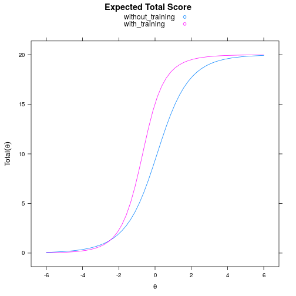

```r
plot(mod.ind)
```

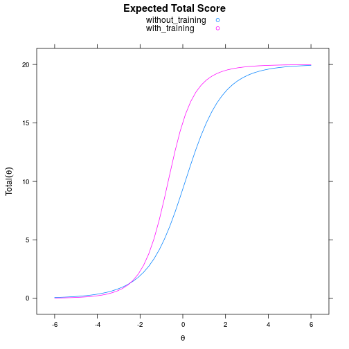

```r
plot(mod.ind, type = 'score')
```

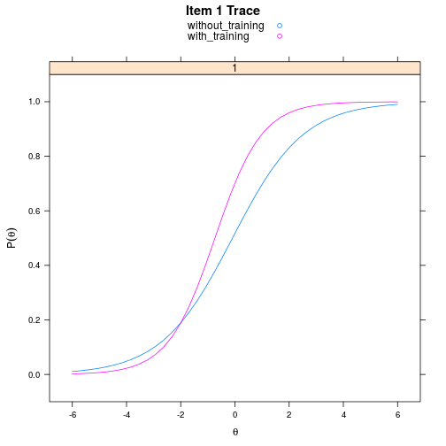

```r
itemplot(mod.ind, 1)
```

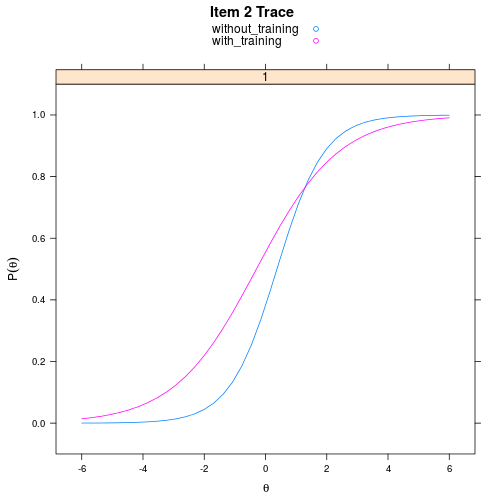

```r
itemplot(mod.ind, 2)
```

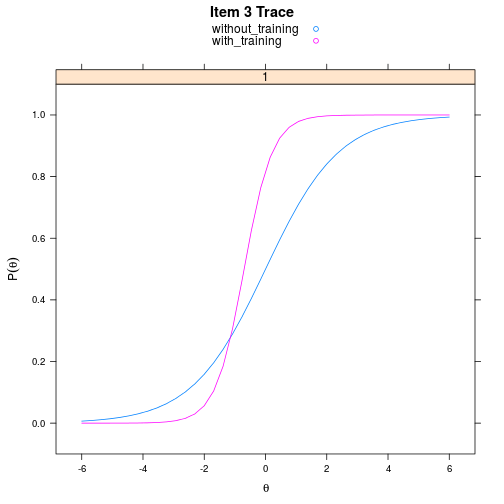

```r
itemplot(mod.ind, 3)
```

### 4) The items appear to be behaving differently for each group, which is an indication that there are either population difference between the groups, the items are showing DIF, or both. There are two ways to go about testing group differences: constrain parameters from the independent model (above) and determine if these constraints make the model fit worse, or free parameters in the fully equal model to determine if the fit improves. We will use the latter approach.

### Fit a less constrained versions of the completely equal model where the mean and variance for the second group is freed, but intercepts and slopes are still constrained to be equal. Hint: See the `invariance = ''` argument in `?multipleGroup`. Compare these models to determine if group differences exist.

```r
mod.freegroup <- multipleGroup(data, 1, group=group,
                      invariance = c('intercepts','slopes', 'free_means', 'free_varcov'))
```

```
##
Iteration: 1, Log-Lik: -23087.203, Max-Change: 0.71338
Iteration: 2, Log-Lik: -22393.097, Max-Change: 0.30075
Iteration: 3, Log-Lik: -22326.457, Max-Change: 0.15147
Iteration: 4, Log-Lik: -22305.580, Max-Change: 0.07045
Iteration: 5, Log-Lik: -22292.150, Max-Change: 0.07255
Iteration: 6, Log-Lik: -22281.992, Max-Change: 0.05536
Iteration: 7, Log-Lik: -22273.812, Max-Change: 0.05456
Iteration: 8, Log-Lik: -22267.018, Max-Change: 0.04475
Iteration: 9, Log-Lik: -22261.447, Max-Change: 0.04301
Iteration: 10, Log-Lik: -22256.755, Max-Change: 0.04110
Iteration: 11, Log-Lik: -22252.887, Max-Change: 0.03821
Iteration: 12, Log-Lik: -22249.362, Max-Change: 0.03416
Iteration: 13, Log-Lik: -22241.496, Max-Change: 0.04907
Iteration: 14, Log-Lik: -22238.864, Max-Change: 0.02339
Iteration: 15, Log-Lik: -22237.472, Max-Change: 0.02107
Iteration: 16, Log-Lik: -22233.220, Max-Change: 0.05003
Iteration: 17, Log-Lik: -22232.097, Max-Change: 0.01058
Iteration: 18, Log-Lik: -22231.643, Max-Change: 0.01046
Iteration: 19, Log-Lik: -22230.306, Max-Change: 0.03377
Iteration: 20, Log-Lik: -22229.758, Max-Change: 0.00938
Iteration: 21, Log-Lik: -22229.597, Max-Change: 0.00617
Iteration: 22, Log-Lik: -22229.266, Max-Change: 0.01426
Iteration: 23, Log-Lik: -22229.089, Max-Change: 0.00597
Iteration: 24, Log-Lik: -22229.016, Max-Change: 0.00398
Iteration: 25, Log-Lik: -22228.882, Max-Change: 0.00976
Iteration: 26, Log-Lik: -22228.778, Max-Change: 0.00422
Iteration: 27, Log-Lik: -22228.742, Max-Change: 0.00263
Iteration: 28, Log-Lik: -22228.699, Max-Change: 0.00368
Iteration: 29, Log-Lik: -22228.663, Max-Change: 0.00210
Iteration: 30, Log-Lik: -22228.645, Max-Change: 0.00155
Iteration: 31, Log-Lik: -22228.623, Max-Change: 0.00251
Iteration: 32, Log-Lik: -22228.601, Max-Change: 0.00152
Iteration: 33, Log-Lik: -22228.589, Max-Change: 0.00104
Iteration: 34, Log-Lik: -22228.576, Max-Change: 0.00257
Iteration: 35, Log-Lik: -22228.555, Max-Change: 0.00129
Iteration: 36, Log-Lik: -22228.547, Max-Change: 0.00076
Iteration: 37, Log-Lik: -22228.542, Max-Change: 0.00067
Iteration: 38, Log-Lik: -22228.537, Max-Change: 0.00042
Iteration: 39, Log-Lik: -22228.535, Max-Change: 0.00032
Iteration: 40, Log-Lik: -22228.531, Max-Change: 0.00083
Iteration: 41, Log-Lik: -22228.525, Max-Change: 0.00042
Iteration: 42, Log-Lik: -22228.522, Max-Change: 0.00027
Iteration: 43, Log-Lik: -22228.520, Max-Change: 0.00035
Iteration: 44, Log-Lik: -22228.517, Max-Change: 0.00021
Iteration: 45, Log-Lik: -22228.516, Max-Change: 0.00015
Iteration: 46, Log-Lik: -22228.515, Max-Change: 0.00040
Iteration: 47, Log-Lik: -22228.512, Max-Change: 0.00019
Iteration: 48, Log-Lik: -22228.511, Max-Change: 0.00012
Iteration: 49, Log-Lik: -22228.510, Max-Change: 0.00019
Iteration: 50, Log-Lik: -22228.508, Max-Change: 0.00010
Iteration: 51, Log-Lik: -22228.508, Max-Change: 0.00007
```

```r
#MUCH better fit with differing group parameters
anova(mod.freegroup, mod.equal)
```

```
##
## Model 1: multipleGroup(data = data, model = 1, group = group, invariance = c("slopes",
##     "intercepts"))
## Model 2: multipleGroup(data = data, model = 1, group = group, invariance = c("intercepts",
##     "slopes", "free_means", "free_varcov"))
```

```
##        AIC     AICc    SABIC      BIC    logLik      X2  df   p
## 1 44927.24 44928.92 45024.20 45151.28 -22423.62     NaN NaN NaN
## 2 44541.02 44542.86 44642.82 44776.25 -22228.51 390.229   2   0
```

```r
#group with training appears to have a higher group mean, but with more variance
coef(mod.freegroup)[[2]]$GroupPars
```

```
##     MEAN_1 COV_11
## par  1.095   2.02
```

### 5) Check to see if the newly acquired model still fits worse than the independent model (it should, but not by much). A difference between the independent and group freed model likely indicates that over and above group differences there may be items that are not functioning the same within each group (DIF). In this case some items may have different slopes, intercepts, or both.

### Begin a DIF search by forming a `for(i in 1:ncol(data))` loop, and free each slope and intercept for each item independently (see the examples in `?multipleGroup` for a demonstration). Compare each one of these models to the model with the freed group parameters (each test should have 2 degrees of freedom).

```r
#information stats pretty close now, but still fits worse than independent model
anova(mod.freegroup, mod.ind)
```

```
##
## Model 1: multipleGroup(data = data, model = 1, group = group, invariance = c("intercepts",
##     "slopes", "free_means", "free_varcov"))
## Model 2: multipleGroup(data = data, model = 1, group = group)
```

```
##        AIC     AICc    SABIC      BIC    logLik      X2  df   p
## 1 44541.02 44542.86 44642.82 44776.25 -22228.51     NaN NaN NaN
## 2 44480.77 44487.52 44674.68 44928.84 -22160.39 136.245  38   0
```

```r
#dif search
estmodels <- vector('list', ncol(data))
itemnames <- colnames(data)
for(i in 1:ncol(data))
    estmodels[[i]] <- multipleGroup(data, 1, group = group, verbose = FALSE,
                             invariance=c('free_means', 'free_varcov',
                             itemnames[-i]))
(anovas <- lapply(estmodels, anova, object2=mod.freegroup))
```

```
##
## Model 1: multipleGroup(data = data, model = 1, group = group, invariance = c("intercepts",
##     "slopes", "free_means", "free_varcov"))
## Model 2: multipleGroup(data = data, model = 1, group = group, invariance = c("free_means",
##     "free_varcov", itemnames[-i]), verbose = FALSE)
##
##
## Model 1: multipleGroup(data = data, model = 1, group = group, invariance = c("intercepts",
##     "slopes", "free_means", "free_varcov"))
## Model 2: multipleGroup(data = data, model = 1, group = group, invariance = c("free_means",
##     "free_varcov", itemnames[-i]), verbose = FALSE)
##
##
## Model 1: multipleGroup(data = data, model = 1, group = group, invariance = c("intercepts",
##     "slopes", "free_means", "free_varcov"))
## Model 2: multipleGroup(data = data, model = 1, group = group, invariance = c("free_means",
##     "free_varcov", itemnames[-i]), verbose = FALSE)
##
##
## Model 1: multipleGroup(data = data, model = 1, group = group, invariance = c("intercepts",
##     "slopes", "free_means", "free_varcov"))
## Model 2: multipleGroup(data = data, model = 1, group = group, invariance = c("free_means",
##     "free_varcov", itemnames[-i]), verbose = FALSE)
##
##
## Model 1: multipleGroup(data = data, model = 1, group = group, invariance = c("intercepts",
##     "slopes", "free_means", "free_varcov"))
## Model 2: multipleGroup(data = data, model = 1, group = group, invariance = c("free_means",
##     "free_varcov", itemnames[-i]), verbose = FALSE)
##
##
## Model 1: multipleGroup(data = data, model = 1, group = group, invariance = c("intercepts",
##     "slopes", "free_means", "free_varcov"))
## Model 2: multipleGroup(data = data, model = 1, group = group, invariance = c("free_means",
##     "free_varcov", itemnames[-i]), verbose = FALSE)
##
##
## Model 1: multipleGroup(data = data, model = 1, group = group, invariance = c("intercepts",
##     "slopes", "free_means", "free_varcov"))
## Model 2: multipleGroup(data = data, model = 1, group = group, invariance = c("free_means",
```

[output cut: 64 more lines]

```
##     "slopes", "free_means", "free_varcov"))
## Model 2: multipleGroup(data = data, model = 1, group = group, invariance = c("free_means",
##     "free_varcov", itemnames[-i]), verbose = FALSE)
##
##
## Model 1: multipleGroup(data = data, model = 1, group = group, invariance = c("intercepts",
##     "slopes", "free_means", "free_varcov"))
## Model 2: multipleGroup(data = data, model = 1, group = group, invariance = c("free_means",
##     "free_varcov", itemnames[-i]), verbose = FALSE)
##
##
## Model 1: multipleGroup(data = data, model = 1, group = group, invariance = c("intercepts",
##     "slopes", "free_means", "free_varcov"))
## Model 2: multipleGroup(data = data, model = 1, group = group, invariance = c("free_means",
##     "free_varcov", itemnames[-i]), verbose = FALSE)
```

```
## [[1]]
##        AIC     AICc    SABIC      BIC    logLik    X2  df      p
## 1 44541.02 44542.86 44642.82 44776.25 -22228.51   NaN NaN    NaN
## 2 44544.12 44546.14 44650.77 44790.56 -22228.06 0.896   2 0.6389
##
## [[2]]
##        AIC     AICc    SABIC      BIC    logLik     X2  df   p
## 1 44541.02 44542.86 44642.82 44776.25 -22228.51    NaN NaN NaN
## 2 44495.17 44497.19 44601.82 44741.61 -22203.58 49.848   2   0
##
## [[3]]
##        AIC     AICc    SABIC      BIC    logLik     X2  df   p
## 1 44541.02 44542.86 44642.82 44776.25 -22228.51    NaN NaN NaN
## 2 44522.49 44524.51 44629.14 44768.93 -22217.24 22.529   2   0
##
## [[4]]
##        AIC     AICc    SABIC      BIC    logLik    X2  df    p
## 1 44541.02 44542.86 44642.82 44776.25 -22228.51   NaN NaN  NaN
## 2 44544.21 44546.24 44650.86 44790.65 -22228.11 0.801   2 0.67
##
## [[5]]
##        AIC     AICc    SABIC      BIC    logLik    X2  df      p
## 1 44541.02 44542.86 44642.82 44776.25 -22228.51   NaN NaN    NaN
## 2 44544.75 44546.78 44651.40 44791.19 -22228.38 0.265   2 0.8759
##
## [[6]]
##        AIC     AICc    SABIC      BIC    logLik    X2  df      p
## 1 44541.02 44542.86 44642.82 44776.25 -22228.51   NaN NaN    NaN
## 2 44543.92 44545.95 44650.57 44790.36 -22227.96 1.094   2 0.5787
##
## [[7]]
##        AIC     AICc    SABIC      BIC    logLik    X2  df      p
## 1 44541.02 44542.86 44642.82 44776.25 -22228.51   NaN NaN    NaN
## 2 44544.03 44546.06 44650.68 44790.47 -22228.02 0.985   2 0.6111
##
## [[8]]
##        AIC     AICc    SABIC      BIC    logLik    X2  df      p
## 1 44541.02 44542.86 44642.82 44776.25 -22228.51   NaN NaN    NaN
## 2 44544.79 44546.82 44651.44 44791.23 -22228.40 0.221   2 0.8954
##
```

[output cut: 44 more lines]

```
##
## [[18]]
##        AIC     AICc    SABIC      BIC    logLik    X2  df      p
## 1 44541.02 44542.86 44642.82 44776.25 -22228.51   NaN NaN    NaN
## 2 44542.68 44544.70 44649.33 44789.12 -22227.34 2.339   2 0.3105
##
## [[19]]
##        AIC     AICc    SABIC      BIC    logLik     X2  df   p
## 1 44541.02 44542.86 44642.82 44776.25 -22228.51    NaN NaN NaN
## 2 44499.77 44501.79 44606.42 44746.21 -22205.88 45.249   2   0
##
## [[20]]
##        AIC     AICc    SABIC      BIC    logLik  X2  df     p
## 1 44541.02 44542.86 44642.82 44776.25 -22228.51 NaN NaN   NaN
## 2 44541.72 44543.74 44648.36 44788.15 -22226.86 3.3   2 0.192
```

### 6) Your search is now nearly over, but the next part requires some more intense hunting. From 5) you should notice that 3 of the DIF tests were significant at the .001 level, indicating that either the slope, intercept, or both parameters should be kept free across the groups.

### Using the `mod2values()` function to help you locate the appropriate parameter numbers, manually set up appropriate `constrain` arguments to isolate the parameters of interest to locate which parameters are showing DIF. Hint: in total there are 3 parameters showing DIF.

```r
(vals <- mod2values(mod.freegroup))
```

```
##                group    item     class   name parnum       value lbound
## 1   without_training  Item_1      dich     a1      1  0.77353908   -Inf
## 2   without_training  Item_1      dich      d      2  0.03690405   -Inf
## 3   without_training  Item_1      dich      g      3  0.00000000   -Inf
## 4   without_training  Item_1      dich      u      4  1.00000000   -Inf
## 5   without_training  Item_2      dich     a1      5  0.71616959   -Inf
## 6   without_training  Item_2      dich      d      6 -0.47611870   -Inf
## 7   without_training  Item_2      dich      g      7  0.00000000   -Inf
## 8   without_training  Item_2      dich      u      8  1.00000000   -Inf
## 9   without_training  Item_3      dich     a1      9  1.16071093   -Inf
## 10  without_training  Item_3      dich      d     10  0.01306587   -Inf
## 11  without_training  Item_3      dich      g     11  0.00000000   -Inf
## 12  without_training  Item_3      dich      u     12  1.00000000   -Inf
## 13  without_training  Item_4      dich     a1     13  1.41265410   -Inf
## 14  without_training  Item_4      dich      d     14 -0.43868712   -Inf
```

[output cut: 315 more lines]

```r
#View(vals)

#item 2
freeint.2 <- multipleGroup(data, 1, group=group,
                             invariance = c('free_means', 'free_varcov', itemnames[-2]),
                             constrain = list(c(5, 87)))
```

```
##
Iteration: 1, Log-Lik: -23087.203, Max-Change: 0.71831
Iteration: 2, Log-Lik: -22391.408, Max-Change: 0.29086
Iteration: 3, Log-Lik: -22325.301, Max-Change: 0.14465
Iteration: 4, Log-Lik: -22304.457, Max-Change: 0.06976
Iteration: 5, Log-Lik: -22292.174, Max-Change: 0.05371
Iteration: 6, Log-Lik: -22281.541, Max-Change: 0.06692
Iteration: 7, Log-Lik: -22273.111, Max-Change: 0.04496
Iteration: 8, Log-Lik: -22266.198, Max-Change: 0.05881
Iteration: 9, Log-Lik: -22260.550, Max-Change: 0.04349
Iteration: 10, Log-Lik: -22255.500, Max-Change: 0.04229
Iteration: 11, Log-Lik: -22251.310, Max-Change: 0.04207
Iteration: 12, Log-Lik: -22247.988, Max-Change: 0.03564
Iteration: 13, Log-Lik: -22240.884, Max-Change: 0.04230
Iteration: 14, Log-Lik: -22238.748, Max-Change: 0.02463
Iteration: 15, Log-Lik: -22237.156, Max-Change: 0.02468
Iteration: 16, Log-Lik: -22232.568, Max-Change: 0.05276
Iteration: 17, Log-Lik: -22231.111, Max-Change: 0.01271
Iteration: 18, Log-Lik: -22230.614, Max-Change: 0.01117
Iteration: 19, Log-Lik: -22229.224, Max-Change: 0.03181
Iteration: 20, Log-Lik: -22228.699, Max-Change: 0.00899
Iteration: 21, Log-Lik: -22228.512, Max-Change: 0.00597
Iteration: 22, Log-Lik: -22228.105, Max-Change: 0.01621
Iteration: 23, Log-Lik: -22227.895, Max-Change: 0.00616
Iteration: 24, Log-Lik: -22227.813, Max-Change: 0.00410
Iteration: 25, Log-Lik: -22227.656, Max-Change: 0.01013
Iteration: 26, Log-Lik: -22227.547, Max-Change: 0.00435
Iteration: 27, Log-Lik: -22227.506, Max-Change: 0.00278
Iteration: 28, Log-Lik: -22227.449, Max-Change: 0.00511
Iteration: 29, Log-Lik: -22227.399, Max-Change: 0.00262
Iteration: 30, Log-Lik: -22227.379, Max-Change: 0.00156
Iteration: 31, Log-Lik: -22227.354, Max-Change: 0.00292
Iteration: 32, Log-Lik: -22227.328, Max-Change: 0.00155
Iteration: 33, Log-Lik: -22227.316, Max-Change: 0.00107
Iteration: 34, Log-Lik: -22227.302, Max-Change: 0.00266
Iteration: 35, Log-Lik: -22227.279, Max-Change: 0.00132
Iteration: 36, Log-Lik: -22227.272, Max-Change: 0.00079
Iteration: 37, Log-Lik: -22227.266, Max-Change: 0.00072
Iteration: 38, Log-Lik: -22227.261, Max-Change: 0.00044
Iteration: 39, Log-Lik: -22227.258, Max-Change: 0.00034
Iteration: 40, Log-Lik: -22227.255, Max-Change: 0.00087
Iteration: 41, Log-Lik: -22227.248, Max-Change: 0.00044
Iteration: 42, Log-Lik: -22227.245, Max-Change: 0.00028
Iteration: 43, Log-Lik: -22227.243, Max-Change: 0.00038
Iteration: 44, Log-Lik: -22227.240, Max-Change: 0.00022
Iteration: 45, Log-Lik: -22227.239, Max-Change: 0.00016
Iteration: 46, Log-Lik: -22227.237, Max-Change: 0.00042
Iteration: 47, Log-Lik: -22227.234, Max-Change: 0.00019
Iteration: 48, Log-Lik: -22227.233, Max-Change: 0.00013
Iteration: 49, Log-Lik: -22227.232, Max-Change: 0.00021
Iteration: 50, Log-Lik: -22227.230, Max-Change: 0.00011
Iteration: 51, Log-Lik: -22227.230, Max-Change: 0.00007
```

```r
freeslope.2 <- multipleGroup(data, 1, group=group,
                           invariance = c('free_means', 'free_varcov', itemnames[-2]),
                           constrain = list(c(6, 88)))
```

```
##
Iteration: 1, Log-Lik: -23087.203, Max-Change: 0.69443
Iteration: 2, Log-Lik: -22379.808, Max-Change: 0.32173
Iteration: 3, Log-Lik: -22303.419, Max-Change: 0.15919
Iteration: 4, Log-Lik: -22280.888, Max-Change: 0.07787
Iteration: 5, Log-Lik: -22267.279, Max-Change: 0.07277
Iteration: 6, Log-Lik: -22257.176, Max-Change: 0.06544
Iteration: 7, Log-Lik: -22247.743, Max-Change: 0.06047
Iteration: 8, Log-Lik: -22240.281, Max-Change: 0.03647
Iteration: 9, Log-Lik: -22235.220, Max-Change: 0.04141
Iteration: 10, Log-Lik: -22230.513, Max-Change: 0.05345
Iteration: 11, Log-Lik: -22226.308, Max-Change: 0.03970
Iteration: 12, Log-Lik: -22222.978, Max-Change: 0.04130
Iteration: 13, Log-Lik: -22217.191, Max-Change: 0.03738
Iteration: 14, Log-Lik: -22214.919, Max-Change: 0.02393
Iteration: 15, Log-Lik: -22213.433, Max-Change: 0.02056
Iteration: 16, Log-Lik: -22210.568, Max-Change: 0.02787
Iteration: 17, Log-Lik: -22209.597, Max-Change: 0.01507
Iteration: 18, Log-Lik: -22208.884, Max-Change: 0.01399
Iteration: 19, Log-Lik: -22206.673, Max-Change: 0.04277
Iteration: 20, Log-Lik: -22205.893, Max-Change: 0.00902
Iteration: 21, Log-Lik: -22205.667, Max-Change: 0.00636
Iteration: 22, Log-Lik: -22205.148, Max-Change: 0.02093
Iteration: 23, Log-Lik: -22204.852, Max-Change: 0.00703
Iteration: 24, Log-Lik: -22204.761, Max-Change: 0.00442
Iteration: 25, Log-Lik: -22204.622, Max-Change: 0.00831
Iteration: 26, Log-Lik: -22204.520, Max-Change: 0.00407
Iteration: 27, Log-Lik: -22204.476, Max-Change: 0.00268
Iteration: 28, Log-Lik: -22204.414, Max-Change: 0.00582
Iteration: 29, Log-Lik: -22204.349, Max-Change: 0.00280
Iteration: 30, Log-Lik: -22204.325, Max-Change: 0.00155
Iteration: 31, Log-Lik: -22204.304, Max-Change: 0.00211
Iteration: 32, Log-Lik: -22204.281, Max-Change: 0.00131
Iteration: 33, Log-Lik: -22204.269, Max-Change: 0.00095
Iteration: 34, Log-Lik: -22204.255, Max-Change: 0.00265
Iteration: 35, Log-Lik: -22204.228, Max-Change: 0.00127
Iteration: 36, Log-Lik: -22204.220, Max-Change: 0.00074
Iteration: 37, Log-Lik: -22204.214, Max-Change: 0.00061
Iteration: 38, Log-Lik: -22204.209, Max-Change: 0.00038
Iteration: 39, Log-Lik: -22204.206, Max-Change: 0.00029
Iteration: 40, Log-Lik: -22204.203, Max-Change: 0.00075
Iteration: 41, Log-Lik: -22204.196, Max-Change: 0.00037
Iteration: 42, Log-Lik: -22204.193, Max-Change: 0.00023
Iteration: 43, Log-Lik: -22204.191, Max-Change: 0.00030
Iteration: 44, Log-Lik: -22204.188, Max-Change: 0.00018
Iteration: 45, Log-Lik: -22204.187, Max-Change: 0.00013
Iteration: 46, Log-Lik: -22204.185, Max-Change: 0.00036
Iteration: 47, Log-Lik: -22204.182, Max-Change: 0.00016
Iteration: 48, Log-Lik: -22204.181, Max-Change: 0.00010
Iteration: 49, Log-Lik: -22204.180, Max-Change: 0.00017
Iteration: 50, Log-Lik: -22204.178, Max-Change: 0.00009
```

```r
anova(freeslope.2, mod.freegroup) #freeing slope is highly significant
```

```
##
## Model 1: multipleGroup(data = data, model = 1, group = group, invariance = c("intercepts",
##     "slopes", "free_means", "free_varcov"))
## Model 2: multipleGroup(data = data, model = 1, group = group, invariance = c("free_means",
##     "free_varcov", itemnames[-2]), constrain = list(c(6, 88)))
```

```
##        AIC     AICc    SABIC      BIC    logLik     X2  df   p
## 1 44541.02 44542.86 44642.82 44776.25 -22228.51    NaN NaN NaN
## 2 44494.36 44496.29 44598.58 44735.20 -22204.18 48.658   1   0
```

```r
anova(freeint.2, mod.freegroup)
```

```
##
## Model 1: multipleGroup(data = data, model = 1, group = group, invariance = c("intercepts",
##     "slopes", "free_means", "free_varcov"))
## Model 2: multipleGroup(data = data, model = 1, group = group, invariance = c("free_means",
##     "free_varcov", itemnames[-2]), constrain = list(c(5, 87)))
```

```
##        AIC     AICc    SABIC      BIC    logLik    X2  df      p
## 1 44541.02 44542.86 44642.82 44776.25 -22228.51   NaN NaN    NaN
## 2 44540.46 44542.39 44644.69 44781.30 -22227.23 2.555   1 0.1099
```

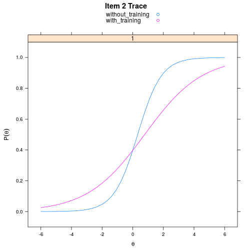

```r
itemplot(freeslope.2, 2)
```

```r
#item 3
freeint.3 <- multipleGroup(data, 1, group=group,
                             invariance = c('free_means', 'free_varcov', itemnames[-3]),
                             constrain = list(c(9, 91)))
```

```
##
Iteration: 1, Log-Lik: -23087.203, Max-Change: 0.69347
Iteration: 2, Log-Lik: -22403.345, Max-Change: 0.31325
Iteration: 3, Log-Lik: -22328.534, Max-Change: 0.14138
Iteration: 4, Log-Lik: -22305.613, Max-Change: 0.06820
Iteration: 5, Log-Lik: -22291.674, Max-Change: 0.07593
Iteration: 6, Log-Lik: -22281.562, Max-Change: 0.05891
Iteration: 7, Log-Lik: -22273.192, Max-Change: 0.06490
Iteration: 8, Log-Lik: -22266.289, Max-Change: 0.05271
Iteration: 9, Log-Lik: -22260.405, Max-Change: 0.05055
Iteration: 10, Log-Lik: -22255.638, Max-Change: 0.03590
Iteration: 11, Log-Lik: -22251.621, Max-Change: 0.04039
Iteration: 12, Log-Lik: -22248.175, Max-Change: 0.04134
Iteration: 13, Log-Lik: -22241.508, Max-Change: 0.03946
Iteration: 14, Log-Lik: -22239.452, Max-Change: 0.02723
Iteration: 15, Log-Lik: -22237.950, Max-Change: 0.02205
Iteration: 16, Log-Lik: -22233.273, Max-Change: 0.05337
Iteration: 17, Log-Lik: -22232.066, Max-Change: 0.01061
Iteration: 18, Log-Lik: -22231.616, Max-Change: 0.01045
Iteration: 19, Log-Lik: -22230.278, Max-Change: 0.03361
Iteration: 20, Log-Lik: -22229.742, Max-Change: 0.00865
Iteration: 21, Log-Lik: -22229.585, Max-Change: 0.00574
Iteration: 22, Log-Lik: -22229.242, Max-Change: 0.01530
Iteration: 23, Log-Lik: -22229.055, Max-Change: 0.00596
Iteration: 24, Log-Lik: -22228.985, Max-Change: 0.00386
Iteration: 25, Log-Lik: -22228.861, Max-Change: 0.00884
Iteration: 26, Log-Lik: -22228.768, Max-Change: 0.00373
Iteration: 27, Log-Lik: -22228.734, Max-Change: 0.00252
Iteration: 28, Log-Lik: -22228.691, Max-Change: 0.00380
Iteration: 29, Log-Lik: -22228.654, Max-Change: 0.00209
Iteration: 30, Log-Lik: -22228.636, Max-Change: 0.00155
Iteration: 31, Log-Lik: -22228.617, Max-Change: 0.00180
Iteration: 32, Log-Lik: -22228.600, Max-Change: 0.00134
Iteration: 33, Log-Lik: -22228.588, Max-Change: 0.00101
Iteration: 34, Log-Lik: -22228.573, Max-Change: 0.00296
Iteration: 35, Log-Lik: -22228.549, Max-Change: 0.00142
Iteration: 36, Log-Lik: -22228.541, Max-Change: 0.00083
Iteration: 37, Log-Lik: -22228.535, Max-Change: 0.00070
Iteration: 38, Log-Lik: -22228.531, Max-Change: 0.00044
Iteration: 39, Log-Lik: -22228.528, Max-Change: 0.00034
Iteration: 40, Log-Lik: -22228.524, Max-Change: 0.00086
Iteration: 41, Log-Lik: -22228.517, Max-Change: 0.00044
Iteration: 42, Log-Lik: -22228.514, Max-Change: 0.00028
Iteration: 43, Log-Lik: -22228.512, Max-Change: 0.00037
Iteration: 44, Log-Lik: -22228.509, Max-Change: 0.00022
Iteration: 45, Log-Lik: -22228.508, Max-Change: 0.00016
Iteration: 46, Log-Lik: -22228.507, Max-Change: 0.00044
Iteration: 47, Log-Lik: -22228.503, Max-Change: 0.00020
Iteration: 48, Log-Lik: -22228.502, Max-Change: 0.00013
Iteration: 49, Log-Lik: -22228.501, Max-Change: 0.00022
Iteration: 50, Log-Lik: -22228.500, Max-Change: 0.00011
Iteration: 51, Log-Lik: -22228.499, Max-Change: 0.00008
```

```r
freeslope.3 <- multipleGroup(data, 1, group=group,
                           invariance = c('free_means', 'free_varcov', itemnames[-3]),
                           constrain = list(c(10, 92)))
```

```
##
Iteration: 1, Log-Lik: -23087.203, Max-Change: 0.68278
Iteration: 2, Log-Lik: -22390.803, Max-Change: 0.26569
Iteration: 3, Log-Lik: -22316.705, Max-Change: 0.15510
Iteration: 4, Log-Lik: -22293.810, Max-Change: 0.06601
Iteration: 5, Log-Lik: -22280.247, Max-Change: 0.07211
Iteration: 6, Log-Lik: -22269.580, Max-Change: 0.06434
Iteration: 7, Log-Lik: -22261.074, Max-Change: 0.05811
Iteration: 8, Log-Lik: -22253.874, Max-Change: 0.04778
Iteration: 9, Log-Lik: -22247.936, Max-Change: 0.04530
Iteration: 10, Log-Lik: -22243.052, Max-Change: 0.04276
Iteration: 11, Log-Lik: -22239.017, Max-Change: 0.03537
Iteration: 12, Log-Lik: -22235.746, Max-Change: 0.03360
Iteration: 13, Log-Lik: -22227.016, Max-Change: 0.06066
Iteration: 14, Log-Lik: -22224.574, Max-Change: 0.01639
Iteration: 15, Log-Lik: -22223.688, Max-Change: 0.01684
Iteration: 16, Log-Lik: -22221.111, Max-Change: 0.03702
Iteration: 17, Log-Lik: -22220.412, Max-Change: 0.00856
Iteration: 18, Log-Lik: -22220.106, Max-Change: 0.00847
Iteration: 19, Log-Lik: -22219.221, Max-Change: 0.02710
Iteration: 20, Log-Lik: -22218.849, Max-Change: 0.00832
Iteration: 21, Log-Lik: -22218.738, Max-Change: 0.00548
Iteration: 22, Log-Lik: -22218.519, Max-Change: 0.01127
Iteration: 23, Log-Lik: -22218.398, Max-Change: 0.00550
Iteration: 24, Log-Lik: -22218.346, Max-Change: 0.00360
Iteration: 25, Log-Lik: -22218.257, Max-Change: 0.00724
Iteration: 26, Log-Lik: -22218.189, Max-Change: 0.00366
Iteration: 27, Log-Lik: -22218.163, Max-Change: 0.00246
Iteration: 28, Log-Lik: -22218.129, Max-Change: 0.00401
Iteration: 29, Log-Lik: -22218.098, Max-Change: 0.00224
Iteration: 30, Log-Lik: -22218.084, Max-Change: 0.00138
Iteration: 31, Log-Lik: -22218.067, Max-Change: 0.00238
Iteration: 32, Log-Lik: -22218.049, Max-Change: 0.00148
Iteration: 33, Log-Lik: -22218.040, Max-Change: 0.00102
Iteration: 34, Log-Lik: -22218.030, Max-Change: 0.00223
Iteration: 35, Log-Lik: -22218.014, Max-Change: 0.00122
Iteration: 36, Log-Lik: -22218.008, Max-Change: 0.00072
Iteration: 37, Log-Lik: -22218.005, Max-Change: 0.00066
Iteration: 38, Log-Lik: -22218.001, Max-Change: 0.00042
Iteration: 39, Log-Lik: -22217.999, Max-Change: 0.00032
Iteration: 40, Log-Lik: -22217.996, Max-Change: 0.00084
Iteration: 41, Log-Lik: -22217.991, Max-Change: 0.00044
Iteration: 42, Log-Lik: -22217.988, Max-Change: 0.00028
Iteration: 43, Log-Lik: -22217.987, Max-Change: 0.00039
Iteration: 44, Log-Lik: -22217.984, Max-Change: 0.00023
Iteration: 45, Log-Lik: -22217.983, Max-Change: 0.00017
Iteration: 46, Log-Lik: -22217.982, Max-Change: 0.00042
Iteration: 47, Log-Lik: -22217.979, Max-Change: 0.00022
Iteration: 48, Log-Lik: -22217.978, Max-Change: 0.00015
Iteration: 49, Log-Lik: -22217.978, Max-Change: 0.00021
Iteration: 50, Log-Lik: -22217.976, Max-Change: 0.00013
Iteration: 51, Log-Lik: -22217.976, Max-Change: 0.00009
```

```r
anova(freeslope.3, mod.freegroup) #freeing slope highly sign
```

```
##
## Model 1: multipleGroup(data = data, model = 1, group = group, invariance = c("intercepts",
##     "slopes", "free_means", "free_varcov"))
## Model 2: multipleGroup(data = data, model = 1, group = group, invariance = c("free_means",
##     "free_varcov", itemnames[-3]), constrain = list(c(10, 92)))
```

```
##        AIC     AICc    SABIC      BIC    logLik     X2  df   p
## 1 44541.02 44542.86 44642.82 44776.25 -22228.51    NaN NaN NaN
## 2 44521.95 44523.89 44626.18 44762.79 -22217.98 21.064   1   0
```

```r
anova(freeint.3, mod.freegroup)
```

```
##
## Model 1: multipleGroup(data = data, model = 1, group = group, invariance = c("intercepts",
##     "slopes", "free_means", "free_varcov"))
## Model 2: multipleGroup(data = data, model = 1, group = group, invariance = c("free_means",
##     "free_varcov", itemnames[-3]), constrain = list(c(9, 91)))
```

```
##        AIC     AICc    SABIC      BIC    logLik    X2  df      p
## 1 44541.02 44542.86 44642.82 44776.25 -22228.51   NaN NaN    NaN
## 2 44543.00 44544.93 44647.22 44783.84 -22228.50 0.017   1 0.8963
```

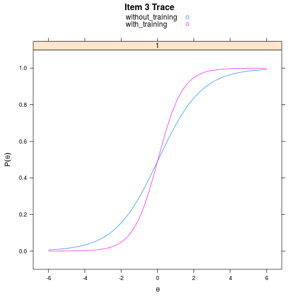

```r
itemplot(freeslope.3, 3)
```

```r
#item 19
freeint.19 <- multipleGroup(data, 1, group=group,
                             invariance = c('free_means', 'free_varcov', itemnames[-19]),
                             constrain = list(c(73, 155)))
```

```
##
Iteration: 1, Log-Lik: -23087.203, Max-Change: 0.72958
Iteration: 2, Log-Lik: -22364.142, Max-Change: 0.32586
Iteration: 3, Log-Lik: -22296.021, Max-Change: 0.11313
Iteration: 4, Log-Lik: -22276.326, Max-Change: 0.06938
Iteration: 5, Log-Lik: -22264.348, Max-Change: 0.06994
Iteration: 6, Log-Lik: -22254.698, Max-Change: 0.05698
Iteration: 7, Log-Lik: -22246.916, Max-Change: 0.04633
Iteration: 8, Log-Lik: -22240.983, Max-Change: 0.04373
Iteration: 9, Log-Lik: -22235.661, Max-Change: 0.05230
Iteration: 10, Log-Lik: -22231.139, Max-Change: 0.04039
Iteration: 11, Log-Lik: -22227.391, Max-Change: 0.04062
Iteration: 12, Log-Lik: -22224.146, Max-Change: 0.03314
Iteration: 13, Log-Lik: -22215.421, Max-Change: 0.06232
Iteration: 14, Log-Lik: -22213.238, Max-Change: 0.01745
Iteration: 15, Log-Lik: -22212.261, Max-Change: 0.01749
Iteration: 16, Log-Lik: -22209.133, Max-Change: 0.04876
Iteration: 17, Log-Lik: -22208.169, Max-Change: 0.00878
Iteration: 18, Log-Lik: -22207.885, Max-Change: 0.00788
Iteration: 19, Log-Lik: -22207.113, Max-Change: 0.02579
Iteration: 20, Log-Lik: -22206.758, Max-Change: 0.00764
Iteration: 21, Log-Lik: -22206.653, Max-Change: 0.00474
Iteration: 22, Log-Lik: -22206.462, Max-Change: 0.01012
Iteration: 23, Log-Lik: -22206.352, Max-Change: 0.00466
Iteration: 24, Log-Lik: -22206.303, Max-Change: 0.00308
Iteration: 25, Log-Lik: -22206.219, Max-Change: 0.00755
Iteration: 26, Log-Lik: -22206.145, Max-Change: 0.00347
Iteration: 27, Log-Lik: -22206.120, Max-Change: 0.00188
Iteration: 28, Log-Lik: -22206.098, Max-Change: 0.00225
Iteration: 29, Log-Lik: -22206.078, Max-Change: 0.00144
Iteration: 30, Log-Lik: -22206.066, Max-Change: 0.00105
Iteration: 31, Log-Lik: -22206.048, Max-Change: 0.00337
Iteration: 32, Log-Lik: -22206.020, Max-Change: 0.00147
Iteration: 33, Log-Lik: -22206.011, Max-Change: 0.00089
Iteration: 34, Log-Lik: -22206.003, Max-Change: 0.00112
Iteration: 35, Log-Lik: -22205.995, Max-Change: 0.00073
Iteration: 36, Log-Lik: -22205.990, Max-Change: 0.00049
Iteration: 37, Log-Lik: -22205.987, Max-Change: 0.00075
Iteration: 38, Log-Lik: -22205.981, Max-Change: 0.00040
Iteration: 39, Log-Lik: -22205.979, Max-Change: 0.00028
Iteration: 40, Log-Lik: -22205.977, Max-Change: 0.00061
Iteration: 41, Log-Lik: -22205.972, Max-Change: 0.00032
Iteration: 42, Log-Lik: -22205.970, Max-Change: 0.00021
Iteration: 43, Log-Lik: -22205.968, Max-Change: 0.00032
Iteration: 44, Log-Lik: -22205.966, Max-Change: 0.00018
Iteration: 45, Log-Lik: -22205.965, Max-Change: 0.00013
Iteration: 46, Log-Lik: -22205.964, Max-Change: 0.00033
Iteration: 47, Log-Lik: -22205.961, Max-Change: 0.00015
Iteration: 48, Log-Lik: -22205.961, Max-Change: 0.00010
```

```r
freeslope.19 <- multipleGroup(data, 1, group=group,
                           invariance = c('free_means', 'free_varcov', itemnames[-19]),
                           constrain = list(c(74, 156)))
```

```
##
Iteration: 1, Log-Lik: -23087.203, Max-Change: 0.77841
Iteration: 2, Log-Lik: -22380.557, Max-Change: 0.27831
Iteration: 3, Log-Lik: -22321.320, Max-Change: 0.09803
Iteration: 4, Log-Lik: -22303.592, Max-Change: 0.06474
Iteration: 5, Log-Lik: -22291.619, Max-Change: 0.06767
Iteration: 6, Log-Lik: -22281.912, Max-Change: 0.05333
Iteration: 7, Log-Lik: -22274.157, Max-Change: 0.04736
Iteration: 8, Log-Lik: -22267.462, Max-Change: 0.05002
Iteration: 9, Log-Lik: -22261.755, Max-Change: 0.05104
Iteration: 10, Log-Lik: -22256.633, Max-Change: 0.03987
Iteration: 11, Log-Lik: -22252.777, Max-Change: 0.03449
Iteration: 12, Log-Lik: -22249.231, Max-Change: 0.03973
Iteration: 13, Log-Lik: -22243.573, Max-Change: 0.03455
Iteration: 14, Log-Lik: -22240.922, Max-Change: 0.02550
Iteration: 15, Log-Lik: -22238.981, Max-Change: 0.02804
Iteration: 16, Log-Lik: -22234.836, Max-Change: 0.03275
Iteration: 17, Log-Lik: -22233.497, Max-Change: 0.01830
Iteration: 18, Log-Lik: -22232.529, Max-Change: 0.01743
Iteration: 19, Log-Lik: -22229.249, Max-Change: 0.04781
Iteration: 20, Log-Lik: -22228.316, Max-Change: 0.00880
Iteration: 21, Log-Lik: -22228.028, Max-Change: 0.00810
Iteration: 22, Log-Lik: -22227.189, Max-Change: 0.02583
Iteration: 23, Log-Lik: -22226.845, Max-Change: 0.00627
Iteration: 24, Log-Lik: -22226.742, Max-Change: 0.00406
Iteration: 25, Log-Lik: -22226.522, Max-Change: 0.01156
Iteration: 26, Log-Lik: -22226.404, Max-Change: 0.00408
Iteration: 27, Log-Lik: -22226.358, Max-Change: 0.00276
Iteration: 28, Log-Lik: -22226.277, Max-Change: 0.00717
Iteration: 29, Log-Lik: -22226.213, Max-Change: 0.00277
Iteration: 30, Log-Lik: -22226.191, Max-Change: 0.00174
Iteration: 31, Log-Lik: -22226.167, Max-Change: 0.00221
Iteration: 32, Log-Lik: -22226.148, Max-Change: 0.00142
Iteration: 33, Log-Lik: -22226.136, Max-Change: 0.00104
Iteration: 34, Log-Lik: -22226.118, Max-Change: 0.00328
Iteration: 35, Log-Lik: -22226.094, Max-Change: 0.00145
Iteration: 36, Log-Lik: -22226.085, Max-Change: 0.00074
Iteration: 37, Log-Lik: -22226.079, Max-Change: 0.00079
Iteration: 38, Log-Lik: -22226.073, Max-Change: 0.00060
Iteration: 39, Log-Lik: -22226.069, Max-Change: 0.00042
Iteration: 40, Log-Lik: -22226.066, Max-Change: 0.00078
Iteration: 41, Log-Lik: -22226.060, Max-Change: 0.00040
Iteration: 42, Log-Lik: -22226.057, Max-Change: 0.00026
Iteration: 43, Log-Lik: -22226.055, Max-Change: 0.00043
Iteration: 44, Log-Lik: -22226.052, Max-Change: 0.00024
Iteration: 45, Log-Lik: -22226.051, Max-Change: 0.00017
Iteration: 46, Log-Lik: -22226.049, Max-Change: 0.00043
Iteration: 47, Log-Lik: -22226.046, Max-Change: 0.00019
Iteration: 48, Log-Lik: -22226.045, Max-Change: 0.00012
Iteration: 49, Log-Lik: -22226.044, Max-Change: 0.00021
Iteration: 50, Log-Lik: -22226.043, Max-Change: 0.00011
Iteration: 51, Log-Lik: -22226.042, Max-Change: 0.00007
```

```r
anova(freeslope.19, mod.freegroup)
```

```
##
## Model 1: multipleGroup(data = data, model = 1, group = group, invariance = c("intercepts",
##     "slopes", "free_means", "free_varcov"))
## Model 2: multipleGroup(data = data, model = 1, group = group, invariance = c("free_means",
##     "free_varcov", itemnames[-19]), constrain = list(c(74, 156)))
```

```
##        AIC     AICc    SABIC      BIC    logLik   X2  df      p
## 1 44541.02 44542.86 44642.82 44776.25 -22228.51  NaN NaN    NaN
## 2 44538.08 44540.02 44642.31 44778.92 -22226.04 4.93   1 0.0264
```

```r
anova(freeint.19, mod.freegroup) #freeing intercept is highly significant
```

```
##
## Model 1: multipleGroup(data = data, model = 1, group = group, invariance = c("intercepts",
##     "slopes", "free_means", "free_varcov"))
## Model 2: multipleGroup(data = data, model = 1, group = group, invariance = c("free_means",
##     "free_varcov", itemnames[-19]), constrain = list(c(73, 155)))
```

```
##        AIC     AICc    SABIC      BIC    logLik     X2  df   p
## 1 44541.02 44542.86 44642.82 44776.25 -22228.51    NaN NaN NaN
## 2 44497.92 44499.86 44602.15 44738.76 -22205.96 45.094   1   0
```

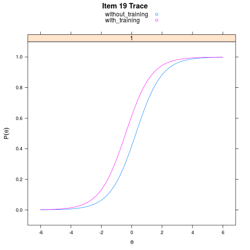

```r
itemplot(freeint.19, 19)
```

```r
#as of version 1.0, constrains can be specified for each item with mirt.model

#item 2
freeintmod.2 <- mirt.model('F = 1-20
                         CONSTRAINB = (1-20, a1), (1, 3-20, d)')
freeslopemod.2 <- mirt.model('F = 1-20
                         CONSTRAINB = (1, 3-20, a1), (1-20, d)')
freeint.2 <- multipleGroup(data, freeintmod.2, group=group,
                             invariance = c('free_means', 'free_varcov'))
```

```
##
Iteration: 1, Log-Lik: -23087.203, Max-Change: 0.71831
Iteration: 2, Log-Lik: -22391.408, Max-Change: 0.29086
Iteration: 3, Log-Lik: -22325.301, Max-Change: 0.14465
Iteration: 4, Log-Lik: -22304.457, Max-Change: 0.06976
Iteration: 5, Log-Lik: -22292.174, Max-Change: 0.05371
Iteration: 6, Log-Lik: -22281.541, Max-Change: 0.06692
Iteration: 7, Log-Lik: -22273.111, Max-Change: 0.04496
Iteration: 8, Log-Lik: -22266.198, Max-Change: 0.05881
Iteration: 9, Log-Lik: -22260.550, Max-Change: 0.04349
Iteration: 10, Log-Lik: -22255.500, Max-Change: 0.04229
Iteration: 11, Log-Lik: -22251.310, Max-Change: 0.04207
Iteration: 12, Log-Lik: -22247.988, Max-Change: 0.03564
Iteration: 13, Log-Lik: -22240.884, Max-Change: 0.04230
Iteration: 14, Log-Lik: -22238.748, Max-Change: 0.02463
Iteration: 15, Log-Lik: -22237.156, Max-Change: 0.02468
Iteration: 16, Log-Lik: -22232.568, Max-Change: 0.05276
Iteration: 17, Log-Lik: -22231.111, Max-Change: 0.01271
Iteration: 18, Log-Lik: -22230.614, Max-Change: 0.01117
Iteration: 19, Log-Lik: -22229.224, Max-Change: 0.03181
Iteration: 20, Log-Lik: -22228.699, Max-Change: 0.00899
Iteration: 21, Log-Lik: -22228.512, Max-Change: 0.00597
Iteration: 22, Log-Lik: -22228.105, Max-Change: 0.01621
Iteration: 23, Log-Lik: -22227.895, Max-Change: 0.00616
Iteration: 24, Log-Lik: -22227.813, Max-Change: 0.00410
Iteration: 25, Log-Lik: -22227.656, Max-Change: 0.01013
Iteration: 26, Log-Lik: -22227.547, Max-Change: 0.00435
Iteration: 27, Log-Lik: -22227.506, Max-Change: 0.00278
Iteration: 28, Log-Lik: -22227.449, Max-Change: 0.00511
Iteration: 29, Log-Lik: -22227.399, Max-Change: 0.00262
Iteration: 30, Log-Lik: -22227.379, Max-Change: 0.00156
Iteration: 31, Log-Lik: -22227.354, Max-Change: 0.00292
Iteration: 32, Log-Lik: -22227.328, Max-Change: 0.00155
Iteration: 33, Log-Lik: -22227.316, Max-Change: 0.00107
Iteration: 34, Log-Lik: -22227.302, Max-Change: 0.00266
Iteration: 35, Log-Lik: -22227.279, Max-Change: 0.00132
Iteration: 36, Log-Lik: -22227.272, Max-Change: 0.00079
Iteration: 37, Log-Lik: -22227.266, Max-Change: 0.00072
Iteration: 38, Log-Lik: -22227.261, Max-Change: 0.00044
Iteration: 39, Log-Lik: -22227.258, Max-Change: 0.00034
Iteration: 40, Log-Lik: -22227.255, Max-Change: 0.00087
Iteration: 41, Log-Lik: -22227.248, Max-Change: 0.00044
Iteration: 42, Log-Lik: -22227.245, Max-Change: 0.00028
Iteration: 43, Log-Lik: -22227.243, Max-Change: 0.00038
Iteration: 44, Log-Lik: -22227.240, Max-Change: 0.00022
Iteration: 45, Log-Lik: -22227.239, Max-Change: 0.00016
Iteration: 46, Log-Lik: -22227.237, Max-Change: 0.00042
Iteration: 47, Log-Lik: -22227.234, Max-Change: 0.00019
Iteration: 48, Log-Lik: -22227.233, Max-Change: 0.00013
Iteration: 49, Log-Lik: -22227.232, Max-Change: 0.00021
Iteration: 50, Log-Lik: -22227.230, Max-Change: 0.00011
Iteration: 51, Log-Lik: -22227.230, Max-Change: 0.00007
```

```r
freeslope.2 <- multipleGroup(data, freeslopemod.2, group=group,
                           invariance = c('free_means', 'free_varcov'))
```

```
##
Iteration: 1, Log-Lik: -23087.203, Max-Change: 0.69443
Iteration: 2, Log-Lik: -22379.808, Max-Change: 0.32173
Iteration: 3, Log-Lik: -22303.419, Max-Change: 0.15919
Iteration: 4, Log-Lik: -22280.888, Max-Change: 0.07787
Iteration: 5, Log-Lik: -22267.279, Max-Change: 0.07277
Iteration: 6, Log-Lik: -22257.176, Max-Change: 0.06544
Iteration: 7, Log-Lik: -22247.743, Max-Change: 0.06047
Iteration: 8, Log-Lik: -22240.281, Max-Change: 0.03647
Iteration: 9, Log-Lik: -22235.220, Max-Change: 0.04141
Iteration: 10, Log-Lik: -22230.513, Max-Change: 0.05345
Iteration: 11, Log-Lik: -22226.308, Max-Change: 0.03970
Iteration: 12, Log-Lik: -22222.978, Max-Change: 0.04130
Iteration: 13, Log-Lik: -22217.191, Max-Change: 0.03738
Iteration: 14, Log-Lik: -22214.919, Max-Change: 0.02393
Iteration: 15, Log-Lik: -22213.433, Max-Change: 0.02056
Iteration: 16, Log-Lik: -22210.568, Max-Change: 0.02787
Iteration: 17, Log-Lik: -22209.597, Max-Change: 0.01507
Iteration: 18, Log-Lik: -22208.884, Max-Change: 0.01399
Iteration: 19, Log-Lik: -22206.673, Max-Change: 0.04277
Iteration: 20, Log-Lik: -22205.893, Max-Change: 0.00902
Iteration: 21, Log-Lik: -22205.667, Max-Change: 0.00636
Iteration: 22, Log-Lik: -22205.148, Max-Change: 0.02093
Iteration: 23, Log-Lik: -22204.852, Max-Change: 0.00703
Iteration: 24, Log-Lik: -22204.761, Max-Change: 0.00442
Iteration: 25, Log-Lik: -22204.622, Max-Change: 0.00831
Iteration: 26, Log-Lik: -22204.520, Max-Change: 0.00407
Iteration: 27, Log-Lik: -22204.476, Max-Change: 0.00268
Iteration: 28, Log-Lik: -22204.414, Max-Change: 0.00582
Iteration: 29, Log-Lik: -22204.349, Max-Change: 0.00280
Iteration: 30, Log-Lik: -22204.325, Max-Change: 0.00155
Iteration: 31, Log-Lik: -22204.304, Max-Change: 0.00211
Iteration: 32, Log-Lik: -22204.281, Max-Change: 0.00131
Iteration: 33, Log-Lik: -22204.269, Max-Change: 0.00095
Iteration: 34, Log-Lik: -22204.255, Max-Change: 0.00265
Iteration: 35, Log-Lik: -22204.228, Max-Change: 0.00127
Iteration: 36, Log-Lik: -22204.220, Max-Change: 0.00074
Iteration: 37, Log-Lik: -22204.214, Max-Change: 0.00061
Iteration: 38, Log-Lik: -22204.209, Max-Change: 0.00038
Iteration: 39, Log-Lik: -22204.206, Max-Change: 0.00029
Iteration: 40, Log-Lik: -22204.203, Max-Change: 0.00075
Iteration: 41, Log-Lik: -22204.196, Max-Change: 0.00037
Iteration: 42, Log-Lik: -22204.193, Max-Change: 0.00023
Iteration: 43, Log-Lik: -22204.191, Max-Change: 0.00030
Iteration: 44, Log-Lik: -22204.188, Max-Change: 0.00018
Iteration: 45, Log-Lik: -22204.187, Max-Change: 0.00013
Iteration: 46, Log-Lik: -22204.185, Max-Change: 0.00036
Iteration: 47, Log-Lik: -22204.182, Max-Change: 0.00016
Iteration: 48, Log-Lik: -22204.181, Max-Change: 0.00010
Iteration: 49, Log-Lik: -22204.180, Max-Change: 0.00017
Iteration: 50, Log-Lik: -22204.178, Max-Change: 0.00009
```

```r
anova(freeslope.2, mod.freegroup) #freeing slope is highly significant
```

```
##
## Model 1: multipleGroup(data = data, model = 1, group = group, invariance = c("intercepts",
##     "slopes", "free_means", "free_varcov"))
## Model 2: multipleGroup(data = data, model = freeslopemod.2, group = group,
##     invariance = c("free_means", "free_varcov"))
```

```
##        AIC     AICc    SABIC      BIC    logLik     X2  df   p
## 1 44541.02 44542.86 44642.82 44776.25 -22228.51    NaN NaN NaN
## 2 44494.36 44496.29 44598.58 44735.20 -22204.18 48.658   1   0
```

```r
anova(freeint.2, mod.freegroup)
```

```
##
## Model 1: multipleGroup(data = data, model = 1, group = group, invariance = c("intercepts",
##     "slopes", "free_means", "free_varcov"))
## Model 2: multipleGroup(data = data, model = freeintmod.2, group = group,
##     invariance = c("free_means", "free_varcov"))
```

```
##        AIC     AICc    SABIC      BIC    logLik    X2  df      p
## 1 44541.02 44542.86 44642.82 44776.25 -22228.51   NaN NaN    NaN
## 2 44540.46 44542.39 44644.69 44781.30 -22227.23 2.555   1 0.1099
```

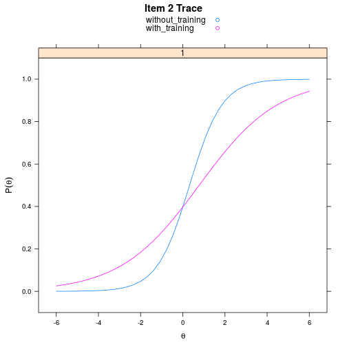

```r
itemplot(freeslope.2, 2)
```

```r
#item 3
freeintmod.3 <- mirt.model('F = 1-20
                         CONSTRAINB = (1-20, a1), (1,2,4-20, d)')
freeslopemod.3 <- mirt.model('F = 1-20
                         CONSTRAINB = (1,2,4-20, a1), (1-20, d)')
freeint.3 <- multipleGroup(data, freeintmod.3, group=group,
                             invariance = c('free_means', 'free_varcov'))
```

```
##
Iteration: 1, Log-Lik: -23087.203, Max-Change: 0.69347
Iteration: 2, Log-Lik: -22403.345, Max-Change: 0.31325
Iteration: 3, Log-Lik: -22328.534, Max-Change: 0.14138
Iteration: 4, Log-Lik: -22305.613, Max-Change: 0.06820
Iteration: 5, Log-Lik: -22291.674, Max-Change: 0.07593
Iteration: 6, Log-Lik: -22281.562, Max-Change: 0.05891
Iteration: 7, Log-Lik: -22273.192, Max-Change: 0.06490
Iteration: 8, Log-Lik: -22266.289, Max-Change: 0.05271
Iteration: 9, Log-Lik: -22260.405, Max-Change: 0.05055
Iteration: 10, Log-Lik: -22255.638, Max-Change: 0.03590
Iteration: 11, Log-Lik: -22251.621, Max-Change: 0.04039
Iteration: 12, Log-Lik: -22248.175, Max-Change: 0.04134
Iteration: 13, Log-Lik: -22241.508, Max-Change: 0.03946
Iteration: 14, Log-Lik: -22239.452, Max-Change: 0.02723
Iteration: 15, Log-Lik: -22237.950, Max-Change: 0.02205
Iteration: 16, Log-Lik: -22233.273, Max-Change: 0.05337
Iteration: 17, Log-Lik: -22232.066, Max-Change: 0.01061
Iteration: 18, Log-Lik: -22231.616, Max-Change: 0.01045
Iteration: 19, Log-Lik: -22230.278, Max-Change: 0.03361
Iteration: 20, Log-Lik: -22229.742, Max-Change: 0.00865
Iteration: 21, Log-Lik: -22229.585, Max-Change: 0.00574
Iteration: 22, Log-Lik: -22229.242, Max-Change: 0.01530
Iteration: 23, Log-Lik: -22229.055, Max-Change: 0.00596
Iteration: 24, Log-Lik: -22228.985, Max-Change: 0.00386
Iteration: 25, Log-Lik: -22228.861, Max-Change: 0.00884
Iteration: 26, Log-Lik: -22228.768, Max-Change: 0.00373
Iteration: 27, Log-Lik: -22228.734, Max-Change: 0.00252
Iteration: 28, Log-Lik: -22228.691, Max-Change: 0.00380
Iteration: 29, Log-Lik: -22228.654, Max-Change: 0.00209
Iteration: 30, Log-Lik: -22228.636, Max-Change: 0.00155
Iteration: 31, Log-Lik: -22228.617, Max-Change: 0.00180
Iteration: 32, Log-Lik: -22228.600, Max-Change: 0.00134
Iteration: 33, Log-Lik: -22228.588, Max-Change: 0.00101
Iteration: 34, Log-Lik: -22228.573, Max-Change: 0.00296
Iteration: 35, Log-Lik: -22228.549, Max-Change: 0.00142
Iteration: 36, Log-Lik: -22228.541, Max-Change: 0.00083
Iteration: 37, Log-Lik: -22228.535, Max-Change: 0.00070
Iteration: 38, Log-Lik: -22228.531, Max-Change: 0.00044
Iteration: 39, Log-Lik: -22228.528, Max-Change: 0.00034
Iteration: 40, Log-Lik: -22228.524, Max-Change: 0.00086
Iteration: 41, Log-Lik: -22228.517, Max-Change: 0.00044
Iteration: 42, Log-Lik: -22228.514, Max-Change: 0.00028
Iteration: 43, Log-Lik: -22228.512, Max-Change: 0.00037
Iteration: 44, Log-Lik: -22228.509, Max-Change: 0.00022
Iteration: 45, Log-Lik: -22228.508, Max-Change: 0.00016
Iteration: 46, Log-Lik: -22228.507, Max-Change: 0.00044
Iteration: 47, Log-Lik: -22228.503, Max-Change: 0.00020
Iteration: 48, Log-Lik: -22228.502, Max-Change: 0.00013
Iteration: 49, Log-Lik: -22228.501, Max-Change: 0.00022
Iteration: 50, Log-Lik: -22228.500, Max-Change: 0.00011
Iteration: 51, Log-Lik: -22228.499, Max-Change: 0.00008
```

```r
freeslope.3 <- multipleGroup(data, freeslopemod.3, group=group,
                           invariance = c('free_means', 'free_varcov'))
```

```
##
Iteration: 1, Log-Lik: -23087.203, Max-Change: 0.68278
Iteration: 2, Log-Lik: -22390.803, Max-Change: 0.26569
Iteration: 3, Log-Lik: -22316.705, Max-Change: 0.15510
Iteration: 4, Log-Lik: -22293.810, Max-Change: 0.06601
Iteration: 5, Log-Lik: -22280.247, Max-Change: 0.07211
Iteration: 6, Log-Lik: -22269.580, Max-Change: 0.06434
Iteration: 7, Log-Lik: -22261.074, Max-Change: 0.05811
Iteration: 8, Log-Lik: -22253.874, Max-Change: 0.04778
Iteration: 9, Log-Lik: -22247.936, Max-Change: 0.04530
Iteration: 10, Log-Lik: -22243.052, Max-Change: 0.04276
Iteration: 11, Log-Lik: -22239.017, Max-Change: 0.03537
Iteration: 12, Log-Lik: -22235.746, Max-Change: 0.03360
Iteration: 13, Log-Lik: -22227.016, Max-Change: 0.06066
Iteration: 14, Log-Lik: -22224.574, Max-Change: 0.01639
Iteration: 15, Log-Lik: -22223.688, Max-Change: 0.01684
Iteration: 16, Log-Lik: -22221.111, Max-Change: 0.03702
Iteration: 17, Log-Lik: -22220.412, Max-Change: 0.00856
Iteration: 18, Log-Lik: -22220.106, Max-Change: 0.00847
Iteration: 19, Log-Lik: -22219.221, Max-Change: 0.02710
Iteration: 20, Log-Lik: -22218.849, Max-Change: 0.00832
Iteration: 21, Log-Lik: -22218.738, Max-Change: 0.00548
Iteration: 22, Log-Lik: -22218.519, Max-Change: 0.01127
Iteration: 23, Log-Lik: -22218.398, Max-Change: 0.00550
Iteration: 24, Log-Lik: -22218.346, Max-Change: 0.00360
Iteration: 25, Log-Lik: -22218.257, Max-Change: 0.00724
Iteration: 26, Log-Lik: -22218.189, Max-Change: 0.00366
Iteration: 27, Log-Lik: -22218.163, Max-Change: 0.00246
Iteration: 28, Log-Lik: -22218.129, Max-Change: 0.00401
Iteration: 29, Log-Lik: -22218.098, Max-Change: 0.00224
Iteration: 30, Log-Lik: -22218.084, Max-Change: 0.00138
Iteration: 31, Log-Lik: -22218.067, Max-Change: 0.00238
Iteration: 32, Log-Lik: -22218.049, Max-Change: 0.00148
Iteration: 33, Log-Lik: -22218.040, Max-Change: 0.00102
Iteration: 34, Log-Lik: -22218.030, Max-Change: 0.00223
Iteration: 35, Log-Lik: -22218.014, Max-Change: 0.00122
Iteration: 36, Log-Lik: -22218.008, Max-Change: 0.00072
Iteration: 37, Log-Lik: -22218.005, Max-Change: 0.00066
Iteration: 38, Log-Lik: -22218.001, Max-Change: 0.00042
Iteration: 39, Log-Lik: -22217.999, Max-Change: 0.00032
Iteration: 40, Log-Lik: -22217.996, Max-Change: 0.00084
Iteration: 41, Log-Lik: -22217.991, Max-Change: 0.00044
Iteration: 42, Log-Lik: -22217.988, Max-Change: 0.00028
Iteration: 43, Log-Lik: -22217.987, Max-Change: 0.00039
Iteration: 44, Log-Lik: -22217.984, Max-Change: 0.00023
Iteration: 45, Log-Lik: -22217.983, Max-Change: 0.00017
Iteration: 46, Log-Lik: -22217.982, Max-Change: 0.00042
Iteration: 47, Log-Lik: -22217.979, Max-Change: 0.00022
Iteration: 48, Log-Lik: -22217.978, Max-Change: 0.00015
Iteration: 49, Log-Lik: -22217.978, Max-Change: 0.00021
Iteration: 50, Log-Lik: -22217.976, Max-Change: 0.00013
Iteration: 51, Log-Lik: -22217.976, Max-Change: 0.00009
```

```r
anova(freeslope.3, mod.freegroup) #freeing slope highly sig
```

```
##
## Model 1: multipleGroup(data = data, model = 1, group = group, invariance = c("intercepts",
##     "slopes", "free_means", "free_varcov"))
## Model 2: multipleGroup(data = data, model = freeslopemod.3, group = group,
##     invariance = c("free_means", "free_varcov"))
```

```
##        AIC     AICc    SABIC      BIC    logLik     X2  df   p
## 1 44541.02 44542.86 44642.82 44776.25 -22228.51    NaN NaN NaN
## 2 44521.95 44523.89 44626.18 44762.79 -22217.98 21.064   1   0
```

```r
anova(freeint.3, mod.freegroup)
```

```
##
## Model 1: multipleGroup(data = data, model = 1, group = group, invariance = c("intercepts",
##     "slopes", "free_means", "free_varcov"))
## Model 2: multipleGroup(data = data, model = freeintmod.3, group = group,
##     invariance = c("free_means", "free_varcov"))
```

```
##        AIC     AICc    SABIC      BIC    logLik    X2  df      p
## 1 44541.02 44542.86 44642.82 44776.25 -22228.51   NaN NaN    NaN
## 2 44543.00 44544.93 44647.22 44783.84 -22228.50 0.017   1 0.8963
```

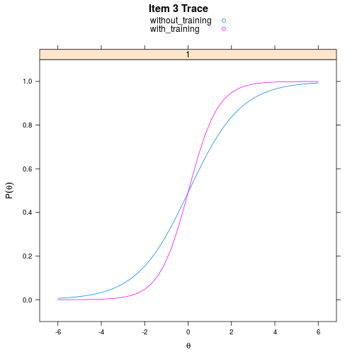

```r
itemplot(freeslope.3, 3)
```

```r
#item 19
freeintmod.19 <- mirt.model('F = 1-20
                         CONSTRAINB = (1-20, a1), (1-18, 20, d)')
freeslopemod.19 <- mirt.model('F = 1-20
                         CONSTRAINB = (1-18,20, a1), (1-20, d)')
freeint.19 <- multipleGroup(data, freeintmod.19 , group=group,
                             invariance = c('free_means', 'free_varcov'))
```

```
##
Iteration: 1, Log-Lik: -23087.203, Max-Change: 0.72958
Iteration: 2, Log-Lik: -22364.142, Max-Change: 0.32586
Iteration: 3, Log-Lik: -22296.021, Max-Change: 0.11313
Iteration: 4, Log-Lik: -22276.326, Max-Change: 0.06938
Iteration: 5, Log-Lik: -22264.348, Max-Change: 0.06994
Iteration: 6, Log-Lik: -22254.698, Max-Change: 0.05698
Iteration: 7, Log-Lik: -22246.916, Max-Change: 0.04633
Iteration: 8, Log-Lik: -22240.983, Max-Change: 0.04373
Iteration: 9, Log-Lik: -22235.661, Max-Change: 0.05230
Iteration: 10, Log-Lik: -22231.139, Max-Change: 0.04039
Iteration: 11, Log-Lik: -22227.391, Max-Change: 0.04062
Iteration: 12, Log-Lik: -22224.146, Max-Change: 0.03314
Iteration: 13, Log-Lik: -22215.421, Max-Change: 0.06232
Iteration: 14, Log-Lik: -22213.238, Max-Change: 0.01745
Iteration: 15, Log-Lik: -22212.261, Max-Change: 0.01749
Iteration: 16, Log-Lik: -22209.133, Max-Change: 0.04876
Iteration: 17, Log-Lik: -22208.169, Max-Change: 0.00878
Iteration: 18, Log-Lik: -22207.885, Max-Change: 0.00788
Iteration: 19, Log-Lik: -22207.113, Max-Change: 0.02579
Iteration: 20, Log-Lik: -22206.758, Max-Change: 0.00764
Iteration: 21, Log-Lik: -22206.653, Max-Change: 0.00474
Iteration: 22, Log-Lik: -22206.462, Max-Change: 0.01012
Iteration: 23, Log-Lik: -22206.352, Max-Change: 0.00466
Iteration: 24, Log-Lik: -22206.303, Max-Change: 0.00308
Iteration: 25, Log-Lik: -22206.219, Max-Change: 0.00755
Iteration: 26, Log-Lik: -22206.145, Max-Change: 0.00347
Iteration: 27, Log-Lik: -22206.120, Max-Change: 0.00188
Iteration: 28, Log-Lik: -22206.098, Max-Change: 0.00225
Iteration: 29, Log-Lik: -22206.078, Max-Change: 0.00144
Iteration: 30, Log-Lik: -22206.066, Max-Change: 0.00105
Iteration: 31, Log-Lik: -22206.048, Max-Change: 0.00337
Iteration: 32, Log-Lik: -22206.020, Max-Change: 0.00147
Iteration: 33, Log-Lik: -22206.011, Max-Change: 0.00089
Iteration: 34, Log-Lik: -22206.003, Max-Change: 0.00112
Iteration: 35, Log-Lik: -22205.995, Max-Change: 0.00073
Iteration: 36, Log-Lik: -22205.990, Max-Change: 0.00049
Iteration: 37, Log-Lik: -22205.987, Max-Change: 0.00075
Iteration: 38, Log-Lik: -22205.981, Max-Change: 0.00040
Iteration: 39, Log-Lik: -22205.979, Max-Change: 0.00028
Iteration: 40, Log-Lik: -22205.977, Max-Change: 0.00061
Iteration: 41, Log-Lik: -22205.972, Max-Change: 0.00032
Iteration: 42, Log-Lik: -22205.970, Max-Change: 0.00021
Iteration: 43, Log-Lik: -22205.968, Max-Change: 0.00032
Iteration: 44, Log-Lik: -22205.966, Max-Change: 0.00018
Iteration: 45, Log-Lik: -22205.965, Max-Change: 0.00013
Iteration: 46, Log-Lik: -22205.964, Max-Change: 0.00033
Iteration: 47, Log-Lik: -22205.961, Max-Change: 0.00015
Iteration: 48, Log-Lik: -22205.961, Max-Change: 0.00010
```

```r
freeslope.19 <- multipleGroup(data, freeslopemod.19, group=group,
                           invariance = c('free_means', 'free_varcov'))
```

```
##
Iteration: 1, Log-Lik: -23087.203, Max-Change: 0.77841
Iteration: 2, Log-Lik: -22380.557, Max-Change: 0.27831
Iteration: 3, Log-Lik: -22321.320, Max-Change: 0.09803
Iteration: 4, Log-Lik: -22303.592, Max-Change: 0.06474
Iteration: 5, Log-Lik: -22291.619, Max-Change: 0.06767
Iteration: 6, Log-Lik: -22281.912, Max-Change: 0.05333
Iteration: 7, Log-Lik: -22274.157, Max-Change: 0.04736
Iteration: 8, Log-Lik: -22267.462, Max-Change: 0.05002
Iteration: 9, Log-Lik: -22261.755, Max-Change: 0.05104
Iteration: 10, Log-Lik: -22256.633, Max-Change: 0.03987
Iteration: 11, Log-Lik: -22252.777, Max-Change: 0.03449
Iteration: 12, Log-Lik: -22249.231, Max-Change: 0.03973
Iteration: 13, Log-Lik: -22243.573, Max-Change: 0.03455
Iteration: 14, Log-Lik: -22240.922, Max-Change: 0.02550
Iteration: 15, Log-Lik: -22238.981, Max-Change: 0.02804
Iteration: 16, Log-Lik: -22234.836, Max-Change: 0.03275
Iteration: 17, Log-Lik: -22233.497, Max-Change: 0.01830
Iteration: 18, Log-Lik: -22232.529, Max-Change: 0.01743
Iteration: 19, Log-Lik: -22229.249, Max-Change: 0.04781
Iteration: 20, Log-Lik: -22228.316, Max-Change: 0.00880
Iteration: 21, Log-Lik: -22228.028, Max-Change: 0.00810
Iteration: 22, Log-Lik: -22227.189, Max-Change: 0.02583
Iteration: 23, Log-Lik: -22226.845, Max-Change: 0.00627
Iteration: 24, Log-Lik: -22226.742, Max-Change: 0.00406
Iteration: 25, Log-Lik: -22226.522, Max-Change: 0.01156
Iteration: 26, Log-Lik: -22226.404, Max-Change: 0.00408
Iteration: 27, Log-Lik: -22226.358, Max-Change: 0.00276
Iteration: 28, Log-Lik: -22226.277, Max-Change: 0.00717
Iteration: 29, Log-Lik: -22226.213, Max-Change: 0.00277
Iteration: 30, Log-Lik: -22226.191, Max-Change: 0.00174
Iteration: 31, Log-Lik: -22226.167, Max-Change: 0.00221
Iteration: 32, Log-Lik: -22226.148, Max-Change: 0.00142
Iteration: 33, Log-Lik: -22226.136, Max-Change: 0.00104
Iteration: 34, Log-Lik: -22226.118, Max-Change: 0.00328
Iteration: 35, Log-Lik: -22226.094, Max-Change: 0.00145
Iteration: 36, Log-Lik: -22226.085, Max-Change: 0.00074
Iteration: 37, Log-Lik: -22226.079, Max-Change: 0.00079
Iteration: 38, Log-Lik: -22226.073, Max-Change: 0.00060
Iteration: 39, Log-Lik: -22226.069, Max-Change: 0.00042
Iteration: 40, Log-Lik: -22226.066, Max-Change: 0.00078
Iteration: 41, Log-Lik: -22226.060, Max-Change: 0.00040
Iteration: 42, Log-Lik: -22226.057, Max-Change: 0.00026
Iteration: 43, Log-Lik: -22226.055, Max-Change: 0.00043
Iteration: 44, Log-Lik: -22226.052, Max-Change: 0.00024
Iteration: 45, Log-Lik: -22226.051, Max-Change: 0.00017
Iteration: 46, Log-Lik: -22226.049, Max-Change: 0.00043
Iteration: 47, Log-Lik: -22226.046, Max-Change: 0.00019
Iteration: 48, Log-Lik: -22226.045, Max-Change: 0.00012
Iteration: 49, Log-Lik: -22226.044, Max-Change: 0.00021
Iteration: 50, Log-Lik: -22226.043, Max-Change: 0.00011
Iteration: 51, Log-Lik: -22226.042, Max-Change: 0.00007
```

```r
anova(freeslope.19, mod.freegroup)
```

```
##
## Model 1: multipleGroup(data = data, model = 1, group = group, invariance = c("intercepts",
##     "slopes", "free_means", "free_varcov"))
## Model 2: multipleGroup(data = data, model = freeslopemod.19, group = group,
##     invariance = c("free_means", "free_varcov"))
```

```
##        AIC     AICc    SABIC      BIC    logLik   X2  df      p
## 1 44541.02 44542.86 44642.82 44776.25 -22228.51  NaN NaN    NaN
## 2 44538.08 44540.02 44642.31 44778.92 -22226.04 4.93   1 0.0264
```

```r
anova(freeint.19, mod.freegroup) #freeing intercept is highly significant
```

```
##
## Model 1: multipleGroup(data = data, model = 1, group = group, invariance = c("intercepts",
##     "slopes", "free_means", "free_varcov"))
## Model 2: multipleGroup(data = data, model = freeintmod.19, group = group,
##     invariance = c("free_means", "free_varcov"))
```

```
##        AIC     AICc    SABIC      BIC    logLik     X2  df   p
## 1 44541.02 44542.86 44642.82 44776.25 -22228.51    NaN NaN NaN
## 2 44497.92 44499.86 44602.15 44738.76 -22205.96 45.094   1   0
```

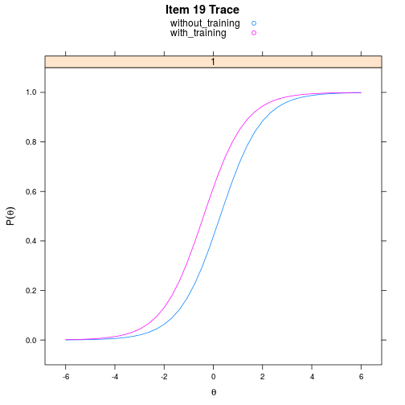

```r
itemplot(freeint.19, 19)
```